# Agrupamento de células e expressão diferencial em transcriptômica de célula única

Minicurso da 70ª RBras · Encontro 1 de 2

Benilton S Carvalho (IMECC/UNICAMP)

## Objetivos

- Introdução à transcriptômica de célula única, com atenção ao agrupamento e à identificação de genes diferencialmente expressos.
- Da matriz de contagens até a definição das populações celulares
- Base em R, com o pacote Seurat, executada no Google Colab.
- A meta é que cada participante entenda por que cada passo é dado e consiga avaliar as próprias decisões

## Etapas da análise

Encontro 1

B01Entrada de dados

B02aObjeto Seurat e doublets

B02bQualidade e filtragem

B03Normalização e escala

B04PCA

B05SCTransform

B06UMAP

Encontro 2

B07Agrupamento e resolução

B08Genes marcadores

B09Expressão diferencial

B10Anotação automatizada

B11Anotação manual

B12Enriquecimento GO

## Organização do encontro 1

| Bloco | Nome | Início | Teoria | Prática |
| --- | --- | --- | --- | --- |
| B00 | Configuração do ambiente | 08:04 | 4 min | 8 min |
| B01 | Entrada de dados | 08:16 | 4 min | 7 min |
| B02a | Objeto Seurat e doublets | 08:27 | 4 min | 11 min |
| B02b | Métricas de qualidade e filtragem | 08:42 | 5 min | 10 min |
| B03 | Normalização, genes variáveis e escalonamento | 08:57 | 5 min | 6 min |
| B04 | PCA e comparações | 09:08 | 5 min | 7 min |
| B05 | Normalização alternativa (SCTransform) | 09:20 | 4 min | 7 min |
| B06 | UMAP | 09:31 | 5 min | 10 min |

# Configuração do ambiente

BLOCO B00

Teoria 4 min · Prática 8 min · Início 08:04

## Configuração do ambiente

- Nesta seção, configuraremos o ambiente de computação necessário
- A configuração envolve usar Shell e R dentro deste notebook.
- R é uma linguagem de programação e ambiente de software para análise de dados, estatísticas e gráficos.
- R é de código aberto

## Pacotes no R

- Um pacote em R é uma coleção de funções, dados e documentação agrupados.
- Pacotes ajudam a estender a funcionalidade principal do R
- Antes de usar um pacote, ele deve ser instalado no seu ambiente.
- Uma vez instalado, o pacote precisa ser carregado em cada sessão em que você deseja usá-lo.

## Prática: bloco B00

8minutos

1. Abra a seção **Bloco B00** do notebook.
2. Execute as 2 células de código, na ordem.

VERIFICACAO B00: 6.0.0

## Enquanto a configuração roda

- Abra o notebook e execute agora a primeira célula de código.
- A instalação dos pacotes leva cerca de 4 minutos.
- Enquanto isso, vamos ver o que é scRNA-seq.

## Por que medir célula a célula?

- Um tecido mistura tipos e estados celulares diferentes.
- O RNA-seq de amostra inteira mede a média de todas as células.
- A média esconde populações raras e estados intermediários.
- O scRNA-seq mede milhares de genes em cada célula.

## Como o experimento é feito

[figure not shown]

Cada gotícula isola uma célula com uma esfera que carrega códigos únicos.

## O que é medido

- Para cada célula, contamos as moléculas de mRNA de cada gene.
- O resultado é uma matriz: genes nas linhas, células nas colunas.
- A matriz é esparsa: a maioria das entradas é zero.
- Zeros misturam genes não expressos com moléculas não capturadas.

## Para que serve o scRNA-seq

- Atlas de tecidos: catalogar tipos celulares (Human Cell Atlas).
- Doenças: comparar populações de pacientes e controles.
- Câncer: heterogeneidade do tumor e do microambiente.
- Desenvolvimento: trajetórias de diferenciação celular.

## Exemplo real: os dados do minicurso

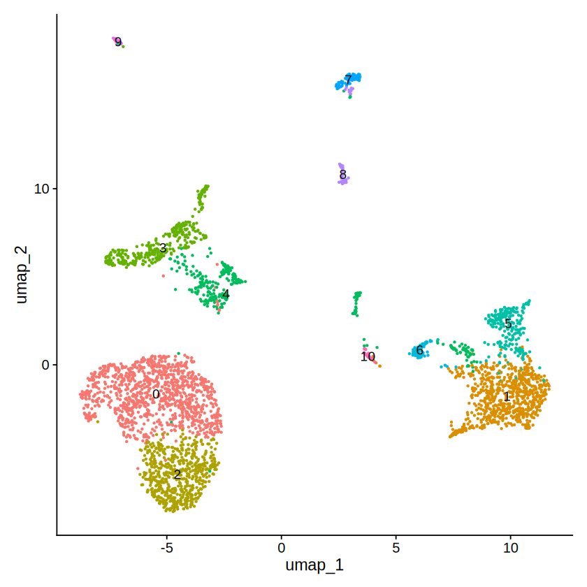

Lavado broncoalveolar de paciente com COVID-19 (Liao et al., 2020). Cada ponto é uma célula; cada número, um grupo.

# Entrada de dados

BLOCO B01

Teoria 4 min · Prática 7 min · Início 08:16

## Etapas do bloco B01

1`baixar()`

2`Read10X_h5()`

## Entrada de dados

- Agora vamos ler dados para uma amostra.
- Os dados do 10X Genomics são geralmente armazenados no formato HDF5 (Hierarchical Data Format versão 5)
- O comando Read10X_h5() é capaz de importar esses dados e carregá-los no R, usando um tipo especial de matriz

## Matriz de contagem UMI esparsa

- Em dados de sequenciamento de RNA de célula única (scRNA-seq), a maioria dos valores na matriz são zeros
- Para lidar com isso de forma eficiente, Seurat usa uma representação de matriz esparsa sempre que possível.
- Matrizes esparsas armazenam apenas os valores diferentes de zero e suas localizações, reduzindo o uso de memória

## O que é um UMI

- UMI: sequência curta e aleatória ligada a cada mRNA capturado.
- Não é gene nem exon: é uma etiqueta de molécula.
- UMIs distintos por gene e célula estimam moléculas de mRNA.
- Cópias de PCR com o mesmo UMI contam uma única vez.

## UMI na prática

[figure not shown]

## Da leitura à matriz

[figure not shown]

## Onde o UMI vira gene

- O gene vem do alinhamento da leitura ao genoma, não do UMI.
- Mesma célula, UMI e gene: as leituras contam uma só molécula.
- Cada valor da matriz é o número de UMIs distintos de um gene em uma célula.
- Isso é feito pelo Cell Ranger, programa da 10x Genomics, antes do notebook.

## Por que 75 mil UMIs e 20 mil genes?

- nCount_RNA soma moléculas de mRNA, não genes.
- Um gene muito expresso tem dezenas a centenas de moléculas.
- Aqui, os genes com mais UMIs são FTL, FTH1, CD74 e B2M.
- nFeature_RNA conta genes com 1 UMI ou mais: até 9.188 aqui.

## Registro dos dados no GEO

[figure not shown]

Imagem da célula 14 do Módulo 04

## Origem dos dados

Liao M, Liu Y, Yuan J, et al. Single-cell landscape of bronchoalveolar immune cells in patients with COVID-19. *Nature Medicine* 26, 842-844 (2020). GEO: GSE145926, amostra GSM4339769.

DOI: 10.1038/s41591-020-0901-9

## Prática: bloco B01

7minutos

1. Abra a seção **Bloco B01** do notebook.
2. Execute as 7 células de código, na ordem.

VERIFICACAO B01: 33539x6249

# Objeto Seurat e doublets

BLOCO B02a

Teoria 4 min · Prática 11 min · Início 08:27

## Etapas do bloco B02a

1`CreateSeuratObject()`

2`as.SingleCellExperiment()`

3`scDblFinder()`

## Controle de Qualidade

- Agora criaremos um objeto Seurat para continuar com a análise.
- Remover genes que são detectados em menos de 3 células.
- Remover células que expressam menos de 200 genes.
- Essas etapas de filtragem ajudam a limpar os dados

## Objeto Seurat e doublets

- Doublets ocorrem quando duas ou mais células são capturadas por engano juntas no mesmo poço
- Para resolver esse problema, usaremos o método `scDblFinder`
- Garanta a reprodutibilidade: definiremos uma semente aleatória usando a função `set.seed()`.
- Vamos encontrar os doublets e removê-los da nossa matriz.

## O objeto Seurat

[figure not shown]

## O objeto Seurat: o que guarda

- Contagens, metadados das células e resultados da análise.
- Cada assay tem layers: counts, data e scale.data.
- meta.data: uma linha por célula, com as métricas de qualidade.
- reductions guarda PCA e UMAP; graphs guarda os vizinhos.

## O objeto SingleCellExperiment

[figure not shown]

## SingleCellExperiment: o que guarda

- Classe do Bioconductor, usada pelo scDblFinder e pelo SingleR.
- assays guarda matrizes genes × células: counts, logcounts.
- rowData descreve os genes; colData descreve as células.
- as.SingleCellExperiment() converte o objeto Seurat.

## Prática: bloco B02a

11minutos

1. Abra a seção **Bloco B02a** do notebook.
2. Execute as 10 células de código, na ordem.

VERIFICACAO B02a: 20271x3949

# Métricas de qualidade e filtragem

BLOCO B02b

Teoria 5 min · Prática 10 min · Início 08:42

## Etapas do bloco B02b

1`PercentageFeatureSet()`

2`VlnPlot()`

3`ggplot()`

4`FeatureScatter()`

5`subset()`

## Métricas de qualidade por célula

- nCount_RNA: total de UMIs da célula.
- nFeature_RNA: número de genes com pelo menos 1 UMI.
- percent.mt: % das UMIs em genes mitocondriais (MT-).
- As três ficam no meta.data do objeto Seurat.

## Faixas esperadas e sinais de alerta

- Poucos genes ou UMIs: gotícula vazia ou célula danificada.
- Muitos genes ou UMIs: possível doublet.
- percent.mt alto: membrana rompida, com perda do mRNA do citoplasma.
- Os limites dependem do tecido e do protocolo.

## As métricas nesta amostra

| Métrica | 1% | Mediana | 99% | Máximo |
| --- | --- | --- | --- | --- |
| nCount_RNA | 566 | 12.969 | 46.063 | 75.319 |
| nFeature_RNA | 246 | 3.335 | 6.848 | 9.188 |
| percent.mt | 0,07 | 1,64 | 77,2 | 91,4 |

## Métricas de qualidade e filtragem 1/3

- A porcentagem de leituras mitocondriais não é calculada automaticamente pelo Cell Ranger.
- Uma alta porcentagem de leituras mitocondriais é geralmente associada a células de alto estresse e baixa qualidade.
- O cálculo é feito somando as contagens (UMIs) no subconjunto e dividindo pela soma total em cada célula.

## Métricas de qualidade e filtragem 3/3

- Frequentemente é mais útil olhar para várias métricas de QC juntas em vez de individualmente.
- Não vemos subpopulações de células notavelmente diferentes por essas métricas de QC.
- Vamos remover células com mais de 10% de leituras mitocondriais, o que pode ser um sinal de dano ex-vivo

## Faixa dinâmica

- Faixa dinâmica: razão entre o maior e o menor valor.
- Aqui, nCount_RNA vai de 502 a 75.319: cerca de 150 vezes.
- Em escala linear, a maioria das células fica espremida à esquerda.
- A escala log10 mostra todas as ordens de grandeza.

## Prática: bloco B02b

10minutos

1. Abra a seção **Bloco B02b** do notebook.
2. Execute as 17 células de código, na ordem.

VERIFICACAO B02b: 20271x3541

## Genes, UMIs e % mitocondrial por célula

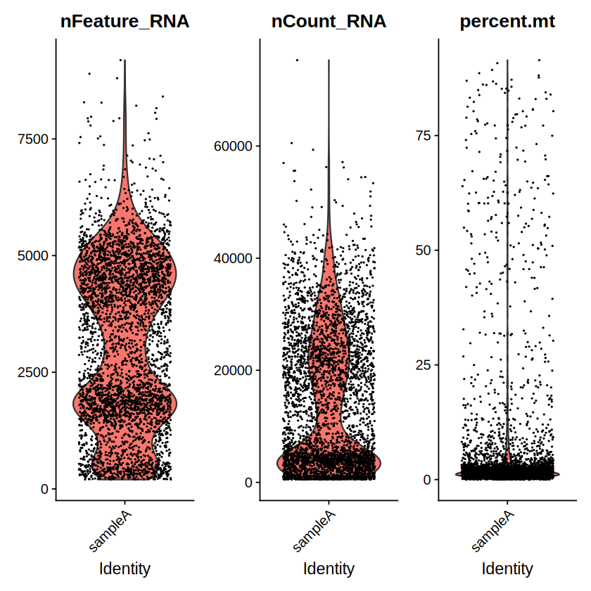

Saída da célula 50 do Módulo 04 · `VlnPlot()`

## Contagens de RNA por célula

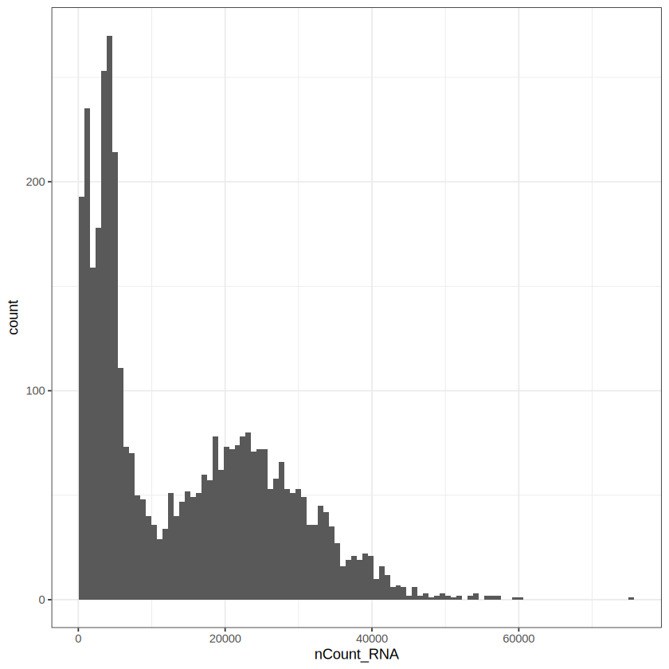

Duas modas: cerca de 4 mil e 25 mil UMIs. Linfócitos têm menos RNA que células mieloides; o PC2 do bloco B04 mostra essa relação.

Saída da célula 52 do Módulo 04 · `ggplot()`

## Contagens de RNA por célula até 1.500

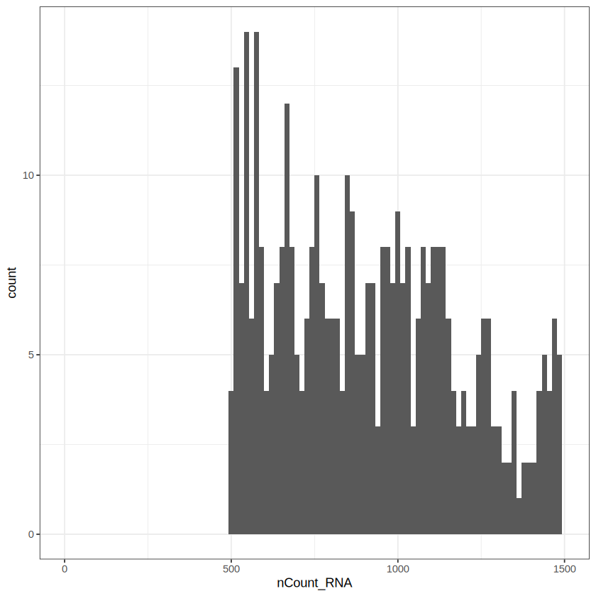

Saída da célula 56 do Módulo 04 · `ggplot()`

# Normalização, genes variáveis e escalonamento

BLOCO B03

Teoria 5 min · Prática 6 min · Início 08:57

## Etapas do bloco B03

1`NormalizeData()`

2`FindVariableFeatures()`

3`VariableFeaturePlot()`

4`ScaleData()`

## Normalização

- A variação na quantidade total de RNA por célula pode influenciar os resultados.
- Uma maneira comum de corrigir isso é normalizar os dados.
- Faremos isso dividindo a contagem de cada gene pela contagem total de UMI daquela célula específica.
- Após a normalização, aplicaremos uma transformação logarítmica.

## Identificar genes variáveis

- O primeiro passo é identificar os genes que mostram a maior variabilidade no conjunto de dados.
- Genes que não variam muito entre células têm menos probabilidade de fornecer informações úteis
- Para fazer isso, primeiro aplicaremos uma transformação de estabilização de variância (vst).

## Escalonando a expressão gênica

- A próxima etapa é escalonar a expressão de cada gene
- Isso significa ajustar os valores para que cada gene tenha média de 0 e variância de 1.
- Ao escalonar a expressão, todos os genes contribuirão igualmente
- Por padrão, apenas os genes mais variáveis são escalonados, sendo estes utilizados para a redução de dimensionalidade.

## Por que usar genes variáveis

- Genes que variam entre células carregam a diferença entre tipos.
- Genes estáveis, como os de manutenção, quase não separam grupos.
- Usar 2.000 genes reduz ruído e tempo de cálculo da PCA.
- A vst corrige a relação média-variância antes da escolha.

## O que o ScaleData faz

- Para cada gene: subtrai a média e divide pelo desvio-padrão.
- Resultado: média 0 e variância 1 em todos os genes (escore z).
- Sem isso, genes muito expressos dominariam a PCA.
- Por padrão, valores acima de 10 são truncados em 10.

## Prática: bloco B03

6minutos

1. Abra a seção **Bloco B03** do notebook.
2. Execute as 9 células de código, na ordem.

VERIFICACAO B03: 2000

## Genes variáveis e os 10 mais variáveis

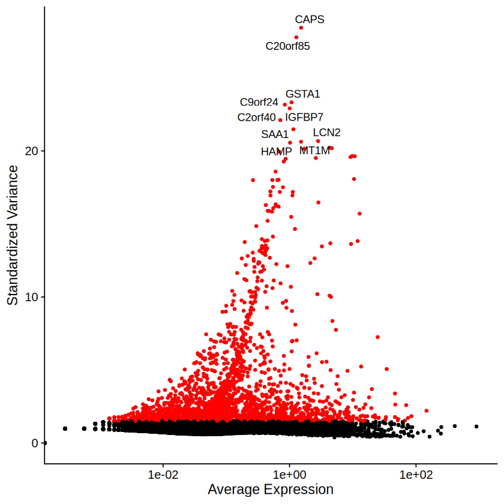

Saída da célula 85 do Módulo 04 · `VariableFeaturePlot()`

# PCA e comparações

BLOCO B04

Teoria 5 min · Prática 7 min · Início 09:08

## Etapas do bloco B04

1`RunPCA()`

2`DimPlot()`

3`ggplot()`

4`DimHeatmap()`

5`FindVariableFeatures()`

6`ScaleData()`

## O que é a PCA

- Encontra direções que maximizam a variância dos dados.
- Cada componente é uma combinação linear dos genes.
- Componentes ortogonais, ordenados pela variância explicada.
- Escore: posição da célula; loading: peso do gene.

## Como a PCA é calculada

- Parte da matriz escalonada dos genes variáveis.
- Usa a decomposição em valores singulares (SVD) da matriz.
- O RunPCA calcula os 50 primeiros componentes por padrão.
- Os primeiros resumem a estrutura; os últimos, ruído.

## Redução de Dimensão 1/2

- Agora, vamos executar nossa primeira redução de dimensionalidade usando PCA (Análise de Componentes Principais).
- PCA é uma técnica usada para reduzir o número de dimensões de dados, preservando o máximo de variabilidade possível.
- Ela faz isso encontrando novas variáveis, chamadas componentes principais, que são combinações das características originais.

## Redução de Dimensão 2/2

- Esses componentes capturam os padrões mais importantes nos dados.
- PCA ajuda a simplificar dados complexos, tornando-os mais fáceis de visualizar e interpretar.
- A variância explicada por cada componente principal é a razão entre cada autovalor e a soma de todos os autovalores.

## PCA e comparações

- Precisamos lembrar que Seurat não computa todos os componentes principais, porque é computacionalmente pesado.
- No nosso caso, ele calculou os primeiros 50 PCs, então toda a inferência deve ser condicional a esses 50 PCs
- Primeiro, vamos preparar os dados não normalizados até o ponto em que nosso conjunto de dados se encontra.

## O que separa as células no PCA

- PC1 positivo: genes de cílios (SNTN, RSPH4A, CFAP43).
- São 94 de 3.541 células: provável epitélio ciliado.
- PC2: linfócitos T (CD3E, IL32) contra mieloides (CD68, LYZ).
- PC2 tem correlação 0,71 com log10 das UMIs por célula.

## Prática: bloco B04

7minutos

1. Abra a seção **Bloco B04** do notebook.
2. Execute as 8 células de código, na ordem.

VERIFICACAO B04: 3541x50

## Células nos dois primeiros PCs

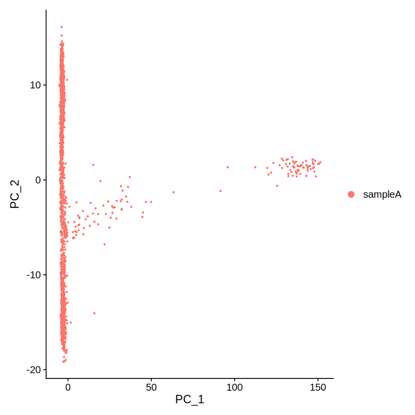

PC1 isola 94 células com genes de cílios: provável epitélio ciliado. PC2 separa linfócitos T de células mieloides.

Saída da célula 94 do Módulo 04 · `RunPCA()`

## Variância explicada por componente

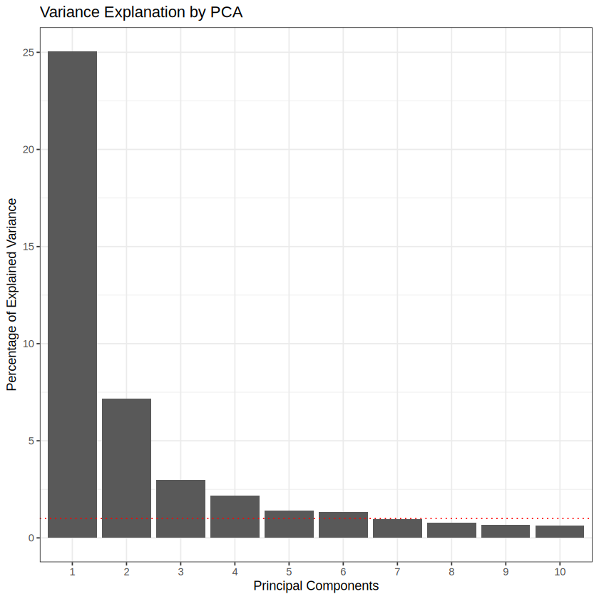

Saída da célula 96 do Módulo 04 · `ggplot()`

## Variância explicada acumulada

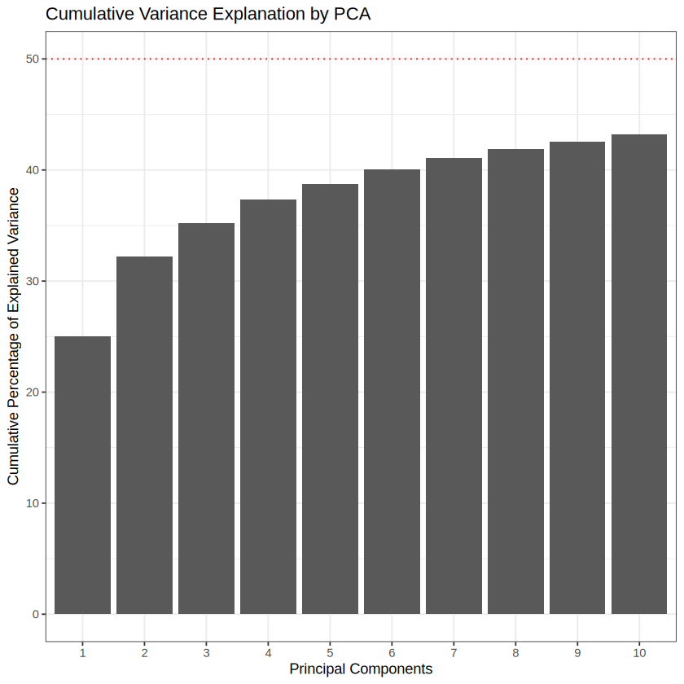

Saída da célula 96 do Módulo 04 · `ggplot()`

# Normalização alternativa (SCTransform)

BLOCO B05

Teoria 4 min · Prática 7 min · Início 09:20

## Etapas do bloco B05

1`SCTransform()`

2`RunPCA()`

3`FeaturePlot()`

## SCTransform: o modelo

- Para cada gene g, um GLM binomial negativo das contagens.
- $\log \mu_{gc} = \beta_{0g} + \beta_{1g} \log_{10} m_c$, com $m_c$ = UMIs da célula c.
- Os parâmetros são suavizados entre genes de expressão parecida.
- Hafemeister e Satija, Genome Biology, 2019.

## SCTransform: resíduos de Pearson

- $z_{gc} = (y_{gc} - \mu_{gc}) / \sqrt{\mu_{gc} + \mu_{gc}^2/\theta_g}$
- O resíduo retira o efeito da profundidade de sequenciamento.
- Substitui NormalizeData, FindVariableFeatures e ScaleData.
- A versão 2 estima os parâmetros com o pacote glmGamPoi.

## Normalização alternativa (SCTransform) 1/2

- O Satijalab desenvolveu seu próprio método de normalização implementado no Seurat, chamado ‘sctransform’.
- O comando executa as mesmas funções que `NormalizeData()`, `ScaleData()` e `FindVariableFeatures()`.
- O método é executado dessa forma quando se trata de uma amostra/indivíduo; para múltiplas amostras, modificações são necessárias

## Normalização alternativa (SCTransform) 2/2

- A execução da ferramenta implica um novo assay no objeto R.
- Este assay contém 3 camadas (counts, data and scaled.data), assim como o assay “RNA” mas transformado com o sctransform.
- Atualmente, o assay ativo é “SCT”, mas você pode selecionar novamente “RNA”.
- Isso influencia onde as funções do Seurat buscarão dados

## Prática: bloco B05

7minutos

1. Abra a seção **Bloco B05** do notebook.
2. Execute as 11 células de código, na ordem.

VERIFICACAO B05: RNA+SCT

## Contagens de RNA no PCA: SCT vs. padrão

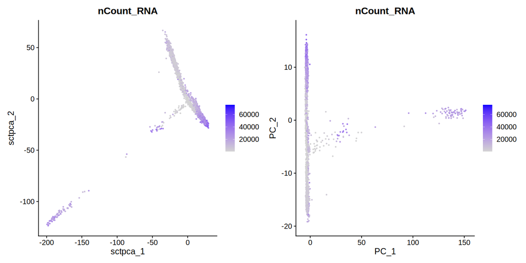

Correlação de log10(UMIs) com o PC2: 0,71 no padrão, -0,54 no SCT. O SCT reduz a associação com a profundidade, mas isso não prova que seja melhor.

Saída da célula 119 do Módulo 04 · `FeaturePlot()`

# UMAP

BLOCO B06

Teoria 5 min · Prática 10 min · Início 09:31

## Etapas do bloco B06

1`ElbowPlot()`

2`RunUMAP()`

3`DimPlot()`

4`FeaturePlot()`

## UMAP 1/3

- UMAP é uma técnica de redução de dimensionalidade não linear usada para visualizar dados de RNA-seq de célula única.
- Ao contrário do PCA, o UMAP é capaz de capturar relacionamentos não lineares mais complexos entre pontos de dados.
- Isso torna o UMAP útil quando os dados têm estruturas intrincadas que não podem ser capturadas por métodos lineares.

## UMAP 2/3

- O UMAP preserva estruturas locais e globais nos dados.
- Isso significa que o UMAP não apenas mantém os relacionamentos entre pontos próximos, mas também tenta manter a estrutura geral
- No entanto, o UMAP é computacionalmente caro e pode ser ruidoso ao lidar com dados de alta dimensão diretamente.

## UMAP 3/3

- Para resolver isso, geralmente realizamos a redução de dimensionalidade inicial usando PCA antes de aplicar o UMAP.
- O PCA simplifica a estrutura e acelera os cálculos do UMAP.
- Além disso, o PCA pode ajudar a remover algum ruído, melhorando a qualidade dos resultados do UMAP.

## Prática: bloco B06

10minutos

1. Abra a seção **Bloco B06** do notebook.
2. Execute as 18 células de código, na ordem.

VERIFICACAO B06: pca+SCT.pca+umap

## Desvio-padrão dos 50 primeiros PCs

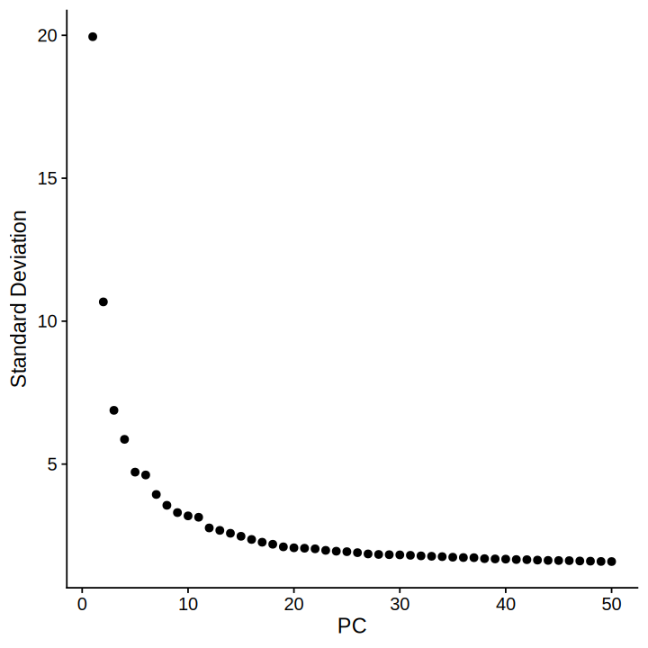

Saída da célula 124 do Módulo 04 · `ElbowPlot()`

## % mitocondrial projetada no UMAP

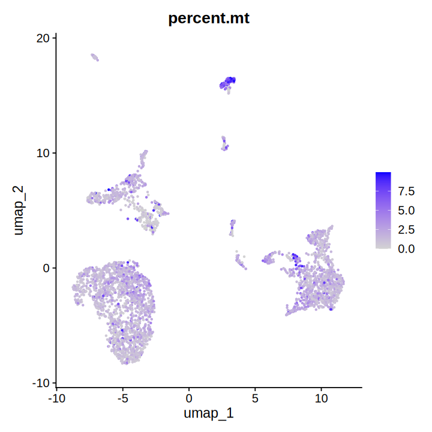

Saída da célula 128 do Módulo 04 · `FeaturePlot()`

## Contagens de RNA projetadas no UMAP

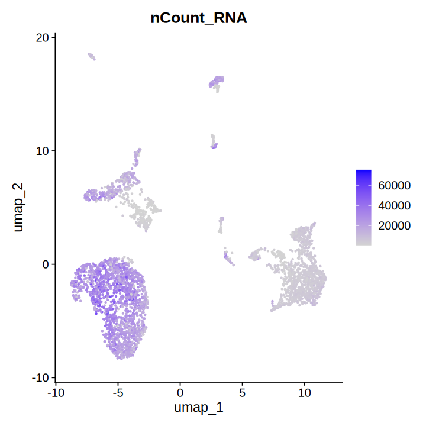

Saída da célula 129 do Módulo 04 · `FeaturePlot()`

## Resumo e próximo encontro

Encontro 1

B01Entrada de dados

B02aObjeto Seurat e doublets

B02bQualidade e filtragem

B03Normalização e escala

B04PCA

B05SCTransform

B06UMAP

Encontro 2

B07Agrupamento e resolução

B08Genes marcadores

B09Expressão diferencial

B10Anotação automatizada

B11Anotação manual

B12Enriquecimento GO